# Breast Cancer Classification

#### A K-NN Application

by Dave Emmanuel Q. Magno and Aries Valeriano

## Executive Summary

The goal of this project is to build a prediction model which take features such as, Age, BMI, Glucose, Insulin, HOMA, Leptin, Adiponectin, Resistin, MCP.1 as predictors to predict presence or absence of breast cancer. These predictors are anthropometric data and parameters which can be gathered in routine blood analysis.

To achieve this goal, the process are based on the whole cyle of data life, which starts from data processing up to predictive modelling. For reproducibility, syntax are shown with some comments to have clear understanding with the process.

In data processing, descriptive features are normalized to make sure all of them has equal contribution to the model trained.

In the data exploration, there are findings that seems to give some useful information, such as the distribution of every descriptive features, correlation between pairs of descriptive features, as well as between every descriptive feature and the target feature. It is then revealed through trying different combination of descriptive features during model training that only Resistin, Glucose, Age, and BMI produced the highest accuracy. Hence, irrelevant descriptive features were remove to reduce training time, improve model, and reduce overfitting.

## Jupyter Display Settings

```python
%%javascript
IPython.OutputArea.prototype._should_scroll = function(lines) {
    return false;
}
```

```python
from IPython.core.display import HTML
HTML("""
<style>
.output_png {
    display: table-cell;
    text-align: center;
    vertical-align: middle;
}
</style>
""")
```

## Necessary Packages

```python
import warnings
warnings.filterwarnings('ignore')
import copy
from typing import Tuple, List

# Data manipulations
import numpy as np
import pandas as pd

# Visualization
%matplotlib inline
import matplotlib.pyplot as plt
import seaborn as sns

from pandas.plotting import scatter_matrix
from pprint import pprint

# Preprocessing and Modeling
from sklearn.feature_selection import SelectKBest
from sklearn.feature_selection import f_classif
from sklearn.ensemble import ExtraTreesClassifier
from sklearn.pipeline import Pipeline
from sklearn.preprocessing import MinMaxScaler
from sklearn.model_selection import train_test_split
from sklearn.neighbors import KNeighborsClassifier
from sklearn import metrics
from sklearn.model_selection import (cross_val_score,
                                     GridSearchCV,
                                     RepeatedKFold)
from sklearn.metrics import classification_report, accuracy_score
from sklearn.utils import shuffle

import scipy.stats as stats

# Plot settings
sns.set()
plt.style.use('seaborn-whitegrid')
```

## Tools

Tools or defined functions that will be used later on. Include here are functions for feature/univariate selection, normalization, hyperparameter optimization etc.

```python
# Feature selection
# Point biserial correlation
def sig_pbc(y: pd.DataFrame, X: pd.DataFrame):
    for i, col in enumerate(X.columns):
        if stats.pointbiserialr(y, X[col])[1] <= 0.05:
            print(f"{X.columns[i]}: ",
                  stats.pointbiserialr(y, X[col])[0])

def find_pbc(y: pd.DataFrame, X: pd.DataFrame) -> List[str]:
    return [X.columns[i] for i, col in enumerate(X.columns)
            if stats.pointbiserialr(y, X[col])[1] <= 0.05]

# Univariate selection
def uni_select(X: pd.DataFrame, y: pd.DataFrame,
               n_features: int=9):
    test_feat = SelectKBest(score_func=f_classif,
                            k=n_features)
    fit = test_feat.fit(X_train, y_train)
    df_scores = pd.DataFrame(fit.scores_)
    df_columns = pd.DataFrame(X_train.columns)
    feat_scores = pd.concat([df_columns, df_scores], axis=1)
    feat_scores.columns = ["Specs", "Score"]
    print(feat_scores.nlargest(n_features, 'Score'))

# Scale features using MinMaxScaler
def scale_feat(X: pd.DataFrame,
               mode=None) -> pd.DataFrame:
    if mode == None:
        mode = MinMaxScaler()
    _ = mode.fit(X)
    _ = _.transform(X)
    return pd.DataFrame(_, columns=X.columns)

# Hyperparameter optimization using GridSearch
def tune_knn(X: pd.DataFrame, y: pd.DataFrame,
             k_range: np.ndarray=None,
             param_grid: dict=None, cv: int=None):
    if k_range == None:
        k_range = np.arange(1, 35)
    if param_grid == None:
        param_grid = {
            'n_neighbors': k_range,
            'weights': ['uniform', 'distance'],
            'metric': ['euclidean', 'manhattan']
        }
    cv = RepeatedKFold(n_splits=10, n_repeats=5, random_state=7)
    clf = GridSearchCV(estimator=KNeighborsClassifier(),
                       param_grid=param_grid,
                       scoring='accuracy',
                       cv=cv,
                       verbose=1,
                       n_jobs=-1)
    clf.fit(X, y)
    return clf

# Testing best model
def test_knn(X_test: pd.DataFrame,
             y_test: pd.DataFrame,
             tuned_model) -> float:
    clf = tuned_model.best_estimator_
    predictions = clf.predict(X_test)
    score = accuracy_score(y_test, predictions)
    return score

# Show results on training and validation
def show_knn_results(best_params: dict, best_score: float,
                     mean_test_score: np.ndarray):
    print("Best model parameters: ")
    print("   metric: ", best_params['metric'])
    print("   n_neighbors: ", best_params['n_neighbors'])
    print("   weights: ", best_params['weights'])
    print()
    print("Best average score: ", round(best_score*100, 2), "percent")
    plt.plot(mean_test_score)
```

## Data Description

The dataset comes from Breast Cancer Coimbra DataSet. It is a multivariate dataset with 116 samples and have the following 10 attributes:

Quantitative:

- Age:
  - The age of the respondent
- BMI:
  - Body mass index measured by kg/m2
- Glucose:
  - Simple sugar from the body of the respondent measured by mg/dL
- Insulin:
  - A peptide hormone produced by beta cells of the pancreatic islets measured by µU/mL
- HOMA
  - Homeostasis model assessment
- Leptin:
  - A hormone predominantly made by adipose cells and enterocytes in the small intestine that helps to regulate energy balance by inhibiting hunger, which in turn diminishes fat storage in adipocytes. Measured by ng/mL
- Adiponectin:
  - A protein hormone and adipokine measured by µg/mL.
- Resistin:
  - A cysteine-rich peptide hormone measured by ng/mL
- MCP-1:
  - Monocyte chemoattractant protein-1 measured by pg/dL

Qualitative:

- Classification:
  - 1 = Healthy controls (or absence of breast cancer)
  - 2 = Patients (or presence of breast cancer)

The objective is, knowing the descriptive features such as Age, BMI, Glucose, Insulin, HOMA, Leptin, Adiponectin, Resistin, MCP-1, build a model that can predict the presence or absence of breast cancer.

These dataset will be split into training set which contains 92 samples and testing set which contains 24 samples. Training set is used for building a model and testing set will be used for assessing the accuracy of the model built from training set.

#### Breast Cancer Coimbra Dataset

```python
df_orig = pd.read_csv("../breast_cancer.csv")
df_orig.sample(5)
```

|  | Age | BMI | Glucose | Insulin | HOMA | Leptin | Adiponectin | Resistin | MCP.1 | Classification |
| --- | --- | --- | --- | --- | --- | --- | --- | --- | --- | --- |
| 9 | 75 | 23.000000 | 83 | 4.952 | 1.013839 | 17.1270 | 11.578990 | 7.09130 | 318.302 | 1 |
| 30 | 66 | 36.212279 | 101 | 15.533 | 3.869788 | 74.7069 | 7.539550 | 22.32024 | 864.968 | 1 |
| 54 | 49 | 20.956608 | 94 | 12.305 | 2.853119 | 11.2406 | 8.412175 | 23.11770 | 573.630 | 2 |
| 69 | 44 | 19.560000 | 114 | 15.890 | 4.468268 | 13.0800 | 20.370000 | 4.62000 | 220.660 | 2 |
| 41 | 76 | 27.200000 | 94 | 14.070 | 3.262364 | 35.8910 | 9.346630 | 8.41560 | 377.227 | 1 |

```python
df_copy = copy.deepcopy(df_orig)
df_copy.sample(5)
```

|  | Age | BMI | Glucose | Insulin | HOMA | Leptin | Adiponectin | Resistin | MCP.1 | Classification |
| --- | --- | --- | --- | --- | --- | --- | --- | --- | --- | --- |
| 58 | 51 | 19.132653 | 93 | 4.364 | 1.001102 | 11.0816 | 5.807620 | 5.57055 | 90.600 | 2 |
| 41 | 76 | 27.200000 | 94 | 14.070 | 3.262364 | 35.8910 | 9.346630 | 8.41560 | 377.227 | 1 |
| 86 | 48 | 28.125000 | 90 | 2.540 | 0.563880 | 15.5325 | 10.222310 | 16.11032 | 1698.440 | 2 |
| 84 | 42 | 29.296875 | 98 | 4.172 | 1.008511 | 12.2617 | 6.695585 | 53.67170 | 1041.843 | 2 |
| 56 | 42 | 21.359915 | 93 | 2.999 | 0.687971 | 19.0826 | 8.462915 | 17.37615 | 321.919 | 2 |

```python
id(df_copy) == id(df_orig)
```

```
False
```

#### Separate features and target

Separate the dataframe for descriptive features and target feature.

```python
X_df = df_copy.iloc[:, 0:-1]
y_df = df_copy.iloc[:, -1]
```

```python
count = np.unique(y_df, return_counts=True)
count
```

```
(array([1, 2]), array([52, 64]))
```

## Data Pre-processing

#### Normalize descriptive features

The descriptive features in the dataset have various unit measure thus, if the algorithm used later on for training the model is sensitive to these variation, then this will cause unequal contribution to the model trained. To address this issue, Min-max scaling is used to normalized the data.

```python
X_df_norm = scale_feat(X_df)
X_df_norm.sample(5)
```

|  | Age | BMI | Glucose | Insulin | HOMA | Leptin | Adiponectin | Resistin | MCP.1 |
| --- | --- | --- | --- | --- | --- | --- | --- | --- | --- |
| 10 | 0.153846 | 0.153399 | 0.127660 | 0.018509 | 0.008137 | 0.119334 | 0.314808 | 0.047028 | 0.186831 |
| 49 | 0.938462 | 0.407249 | 0.255319 | 0.036232 | 0.023968 | 0.041166 | 0.172485 | 0.081170 | 0.112649 |
| 79 | 0.261538 | 0.410850 | 0.262411 | 0.349843 | 0.195435 | 0.469878 | 0.325386 | 0.312112 | 0.446541 |
| 46 | 0.784615 | 0.362714 | 0.241135 | 0.100789 | 0.057188 | 0.716712 | 0.057311 | 0.016312 | 0.097398 |
| 98 | 0.723077 | 0.472346 | 0.312057 | 0.281431 | 0.170911 | 0.572168 | 0.000000 | 0.583494 | 0.127168 |

#### Split data (training and testing)

Split the data into training set and testing set for further analysis. The proportion of data split here is 80/20, since the sample size is small.

```python
X_train, X_test, y_train, y_test = train_test_split(X_df_norm, y_df,
                                                    test_size=0.20,
                                                    random_state=7,
                                                    shuffle=True,
                                                    stratify=y_df)
```

```python
df_train = pd.concat([X_train, y_train], axis=1)
df_test = pd.concat([X_test, y_test], axis=1)
```

```python
print(f" Shape of training set: {X_train.shape}")
print(f" Shape of testing set: {X_test.shape}")
```

```
 Shape of training set: (92, 9)
 Shape of testing set: (24, 9)
```

## Data Exploration

In here, the data is explored to see patterns that may be useful in the analysis. Note that, only the training set are being explored since the testing set will be hold out for the final model.

#### Barplots

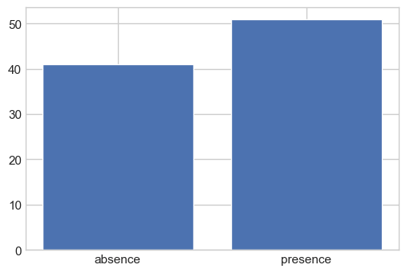

```python
fig=plt.figure(figsize=(6,4), dpi= 100)
target_freq = np.unique(y_train, return_counts=True)
target_freq
plt.bar(["absence", "presence"], target_freq[1])
plt.show()
```

The plot above shows that the number of individual that have breast cancer(or patients) are greater than the number of those individual who do not have (or healthy).

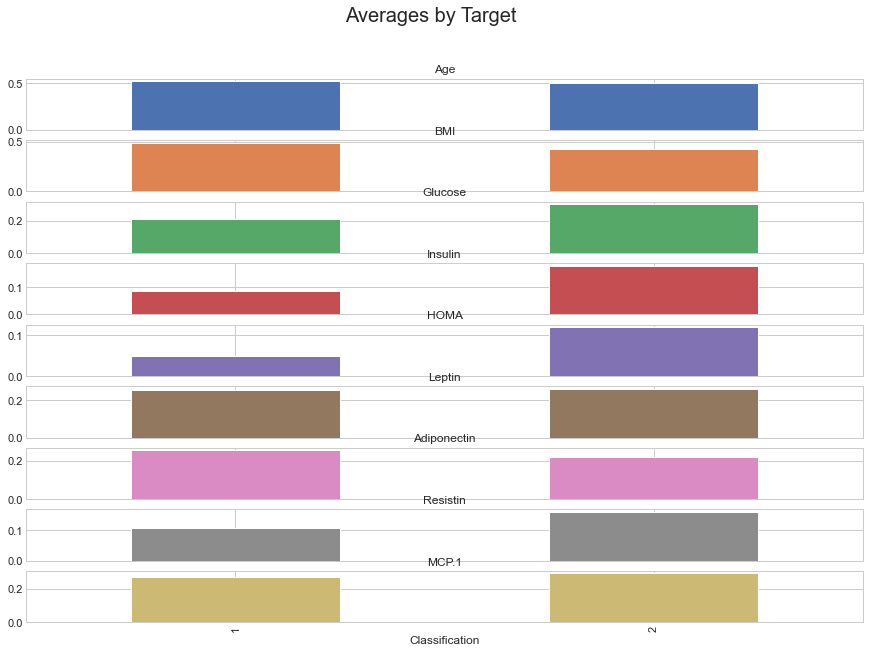

```python
gmean = df_train.groupby('Classification').mean()
fig = plt.figure(figsize=(15,10))
ax = fig.add_subplot(111)
gmean.plot(kind='bar', subplots=True, ax=ax, legend=None, sharex=True)
fig.suptitle("Averages by Target", fontsize=20)
plt.show()
```

#### Checking the distribution

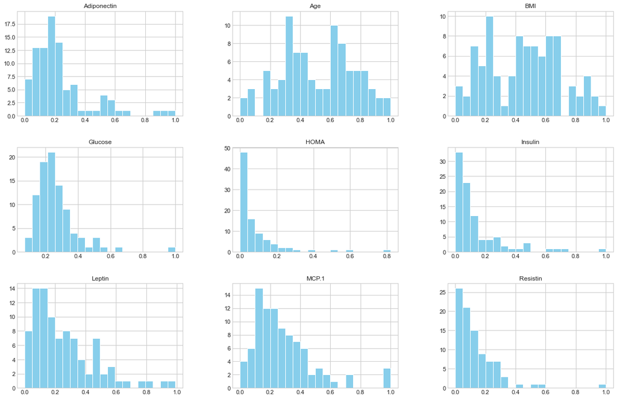

```python
plt.style.use('seaborn-whitegrid')
X_train.hist(bins=20, figsize=(20, 13), color='skyblue')
plt.show()
```

The figure above shows the distribution of every descriptive features. Notice that majority of it are not normally distributed and are skewed to the right. Later, when further analysis is perform. It is necessary to use nonparametric method that does not assume normality. Or just use transformation method to normalize the dataset.

#### Correlation matrix

To assess the relationship between pairs of descriptive features, spearman rho correlation coefficient will be perform. This is a nonparametric test thus, it does not matter if the distribution of features involve are not normally distributed which is the case in this dataset.

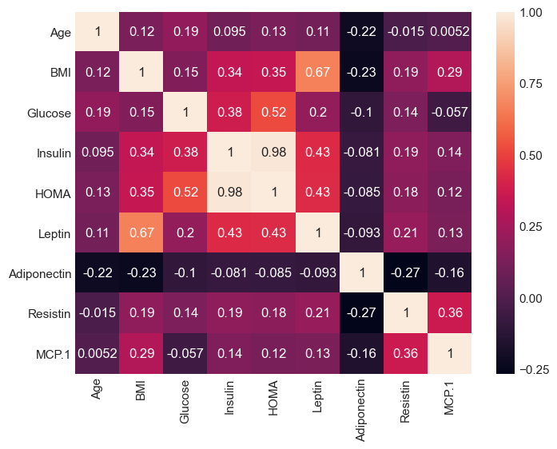

```python
fig=plt.figure(figsize=(8,6), dpi= 100)
sns.heatmap(X_train.corr(method='spearman'), annot=True)
plt.show()
```

The correlation matrix above shows the spearman correlation coefficient for every pair of descriptive features. Notice that Leptin vs HOMA, and Leptin vs Insulin both have and 0.43 correlation coefficient respectively, this implies a slightly positive monotonic relationship between the features. Moreover, Leptin vs BMI and Glucose vs HOMA have correlation coefficient equal to 0.67 and 0.52 respectively. These only implies that there exist a moderate monotonic positive relationship between features. Insulin vs HOMA on the other hand have correlation coefficient equal to 0.98, this imply a highly monotonic positive relationship. From this, we now have idea that for every pair mentioned, if 1 of it say, "Glucose" is correlated to the target feature, then possibly the other one say, "HOMA" is also correlated with the target feature.

## Data Pre-processing

#### Feature selection

In selecting the necessary features relevant to predict the absence or presence of breast cancer, we follow the results of the paper, "Using Resistin, glucose, age and BMI to predict the presence of breast cancer." The dataset used in this project was also taken from the authors of this paper. Based on their results, the presence of breast cancer in women could be predicted on a test data set with sensitivity ranging between 82 percent and 88 percent, and specificially ranging between 85 percent and 90 percent (95 percent CI for the AUC is [0.87, 0.91]). These suggests that considering only resistin, glucose, age, and BMI as predictive features may classify the target well.

In addition, we tried different combination of features but the combination with the highest accuracy can be achieved by selecting resistin, glucose, age, and BMI. Moreover, we also tried to include all features in the dataset, but unfortunately, the accuracy is low, both on the training and testing set. Therefore, based on these observations, we decided to only consider resistin, glucose, age, and BMI as the features of our model.

#### Dataset with Filtered Features

```python
to_filter = ['Glucose', 'Resistin', 'BMI', 'Age']
```

```python
X_train_filtered = X_train.filter(to_filter)
X_test_filtered = X_test.filter(to_filter)
X_train_filtered.sample(5)
```

|  | Glucose | Resistin | BMI | Age |
| --- | --- | --- | --- | --- |
| 70 | 0.226950 | 0.058689 | 0.093524 | 0.323077 |
| 16 | 0.170213 | 0.001394 | 0.181110 | 0.353846 |
| 45 | 0.212766 | 0.044305 | 0.461681 | 0.646154 |
| 38 | 0.304965 | 0.216041 | 0.394843 | 0.553846 |
| 1 | 0.226950 | 0.010826 | 0.114826 | 0.907692 |

## Model training and validation

```python
clf = tune_knn(X_train_filtered, y_train)
```

```
Fitting 50 folds for each of 136 candidates, totalling 6800 fits
```

```
[Parallel(n_jobs=-1)]: Using backend LokyBackend with 4 concurrent workers.
[Parallel(n_jobs=-1)]: Done  68 tasks      | elapsed:    2.1s
[Parallel(n_jobs=-1)]: Done 2380 tasks      | elapsed:    9.4s
[Parallel(n_jobs=-1)]: Done 6380 tasks      | elapsed:   23.1s
[Parallel(n_jobs=-1)]: Done 6800 out of 6800 | elapsed:   24.0s finished
```

```
Best model parameters:
   metric:  manhattan
   n_neighbors:  7
   weights:  distance

Best average score:  78.04 percent
```

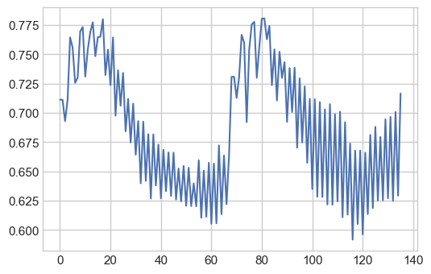

```python
fig=plt.figure(figsize=(6,4), dpi= 100)
show_knn_results(clf.best_params_, clf.best_score_,
                 clf.cv_results_['mean_test_score'])
```

## Model testing

The performance of the model built now will be evaluated using the testing set that was hold out earlier.

```python
test_knn(X_test_filtered, y_test, clf)
```

```
0.8333333333333334
```

As shown above, the accuracy of the predictive model is about 83%, which is actually not so far from the accuracy obtained from using only the training set.

## Conclusion and Recommendations

In this project, we utilized the k-Nearest Neighbors algorithm in classifying the absence or presence of breast cancer in patients. We built a prediction model which takes resistin, glucose, age, and BMI as predictive features to determine whether a patient has a breast cancer or not. The dataset used in this study was the Breast Cancer Coimbra dataset.

Fortunately, the dataset has no missing values. We explored the data and found that the feature variables doesn't seem to have a Normal distribution. In addition, the correlation matrix produced using Spearman shows that the features, insulin and HOMA, have the highest pairwise correlation coefficient.

Moreover, after feature selection 4 descriptive features included in the model. The model still was validated using all the available features in the dataset however, the model with only 4 predictive features produce much higher accuracy.

We tuned the necessary parameters of our model and got the best parameter setting of using manhattan as metric, distance as weights, and k equal to 7. Using these settings, our model achieved an accuracy score of 78.04 percent in the validation stage. This shows that the trained model can predict the absence or presence of breast cancer in patients with an accuracy of about 78.04 percent.

Further researches may use Principal Component Analysis in selecting the features and standardization may be applied in feature scaling.

## References

[1] J. D. Kelleher, B. M. Namee, and A. D'Arcy. *Fundamentals of Machine Learning for Predictive Data Analytics (2nd ed.).* The MIT Press, 2020.

[2] M. Patrício, J. Pereira, J. Crisóstomo, P. Matafome, M. Gomes, R. Seiça, and F. Caramelo. (2018). *Using Resistin, glucose, age and BMI to predict the presence of breast cancer.* BMC Cancer, 18(1).